# Interior of Stars

> **Stellar evolution is the result of a constant fight, against the relentless pull of gravity**.

# Hydrostatic equilibrium

## Derivation of hydrostatic equilibrium

Consider a tiny part in the star with radius $r$, thickness $dr$ and the mass $dm$. We can list all the force it received.

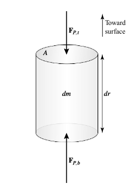

More equation we need:
$$dm\frac{{d^2r}}{dt^2}=F_g+F_{P,t}+F_{P,b}$$
$$F_{P,t}=-(F_{P,b}+dF_{P})\implies-dF_{P}=F_{P,t}+F_{P,b}\implies
dm\frac{{d^2r}}{dt^2}=F_g-dF_{P}$$

And the gravity force at this part is:
$$F_g=-\frac{GM_r\ dm}{r^2}$$

- $M_r$ is the total mass from core to $r$

Note that r has directionaility pointed from core toward outside, so the $F_g$ must be negative

Remember $P\equiv \frac{F}{A}$, Let’s introduce the $\rho$ (Density) to this equation
$$dF_{P}=AdP$$
$$dm=\rho A\ dr\implies\rho A\ dr
\frac{d^2r}{dt^2}=-G \frac{M_r\ \rho A\ dr}{r^2}-A\ dP$$

Simplify it

$$\rho \frac{d^2r}{dt^2}=-G \frac{M_r\rho
}{r^2}-\frac{dP}{dr}$$

Hence, in the condition of hydrostatic equilibrium, acceleration muse be zero. After some arrangement, we finally get this equation
$$\frac{dP}{dr}=-G\frac{M_r\rho}{r^2}=-\rho g$$
- A pressure gradient must exist to counter gravity for a star to be static - Pressure is larger in the interior ## Mass conservation
$$M_r=\frac{4}{3}\pi r^3\rho$$
$$\frac{dM_r}{dr}= 4\pi r^2\rho$$
Pretty easy, isn’t it?

## Luminosity gradient equation

$$dL=\epsilon\ dm$$
$$\frac{dL_{r}}{dr}=4\pi r^2\rho\ \epsilon$$
- $\epsilon$ is the total energy released ## Pressure expression In stars, the total pressure $𝑃$ at any given radius $𝑟$ is the sum of several different types of pressures that help support the star against gravitational collapse. The main components of total pressure in stars are: - Gas Pressure $P_{gas}$ - Radiation Pressure $P_{rad}$ - Degeneracy Pressure $P_{deg}$ (more tricky one)

### Gas pressure

Assuming the gas is ideal, so the gas pressure can be calculated using the ideal gas law:
$$P_{gas}=nk_B T$$

- n is the number density (particles per unit volume)
- $k_B$ is the Boltzmann constant

We need to express number density in terms of mass density
$$n=\frac{\rho}{\mu m_H}$$

- $\rho$ is the mass density of the gas
- $\mu$ is the mean molecular weight (the average number of hydrogen masses per particle)
- $m_H$ is the mass of a hydrogen atom

Hence, we get
$$P_{gas}=\frac{\rho kT}{\mu
m_H}$$

However, the ideal gas law isn’t that ideal sometimes. - The upper limit of velocity - Ignoring quantum effects and relativity

So we have different distribution functions… - Fermi–Dirac - Bose–Einstein

### Radiation pressure

By blackbody radiation, we can write down the equation below
$$P_{rad}=\frac{1}{3}\int_0^\infty h\nu
n_\nu\,d\nu$$
$$P_{rad}=\frac{1}{3}aT^4$$

Finally, we could write down the expression of total pressure
$$P=\frac{\rho k_B T}{\mu m_H}+\frac{1}{3} aT^4$$

As you might notice…we ignore the **Degeneracy pressure**, because it would be quite hard to understand compeletely

### Additional: Degeneracy pressure

## Stellae energy source

### Gravitation evergy

Let’s start with the general equation of gravitional energy
$$U_g=-\frac{GM_r m}{r}$$
Then, by applying the virial theorem and some calculation(We assume that the mass of star is distributed evenly)
$$dU_g=-G\frac{M_r dm}{r}=-G\frac{M_r 4\pi
r^2\rho}{r} dr \ \ \ (\rho\approx\bar{\rho}=\frac{M}{\frac{4}{3}\pi
R^3}\ ,\ \ M_r\approx\frac{4}{3}\pi r^3 \bar{\rho})$$
$$\Rightarrow U_g=-4\pi G\int_0^R M_r\rho r\ dr \approx
-\frac{3}{5}\frac{GM^2}{R}\Rightarrow E\approx
-\frac{3}{10}\frac{GM^2}{R}$$

This is the total mechanical energy of a star ### Kelvin–Helmholtz Timescale

Let’s take our Sun as an example

If the gravitational collapse is the only way for Sun to produce the energy, then we could calculate how long will the sun exist. (Assuming the luminosity of the Sun has been roughly constant)

$$t_{KH} = \frac{\Delta E}{L_\odot} \approx 10^7 \text{ years}$$
However, it’s ridiculous that the Sun will only live for million years based on the result. Therefore, gravitational potential energy alone cannot account for the Sun’s luminosity throughout its entire lifetime.

### Nuclear energy

$$E=mc^2$$
This equation tells everything, so I’ll skip some trivial calculation. Let’s head to the result directly.

$$\mbox{Nuclear timescale}\approx 10^{10} \mbox{yr}$$

### But, How can nuclear reaction take place?

To break the Coulomb barrier: - Thermal energy of gas: $T\approx 10^{10}K$

However, the star basically don’t have that much high temp. With the help of Uncertainty principle, the **Quantum tunneling** happens.

We could derive a $T$ where has the highest percent for particles to break the Coulomb barrier, so-called **Gamow peak**

#### **Derivation:**

Consider the particles in the stars follow the **maxwell-boltzmann distribution**
$$f(E)\varpropto E\ \exp(-E/k_B T)$$
The distribution tells us the higher energy of particles, the lower the amounts.

In order to break the Coulomb barrier, we have the probability fuction for Quantum tunneling
$$P_{tunnel}=\exp(-G/\sqrt{E})$$

- G is the Gamow Constant

Combine these two equations
$$P_{reaction}(E)\varpropto E\ \exp(-E/k_B T)\ \cdot\ \exp(-G/\sqrt{E})$$
If we draw this fuction on the Cartesian coordinate system, we could see a peak, which is the **Gamow peak**

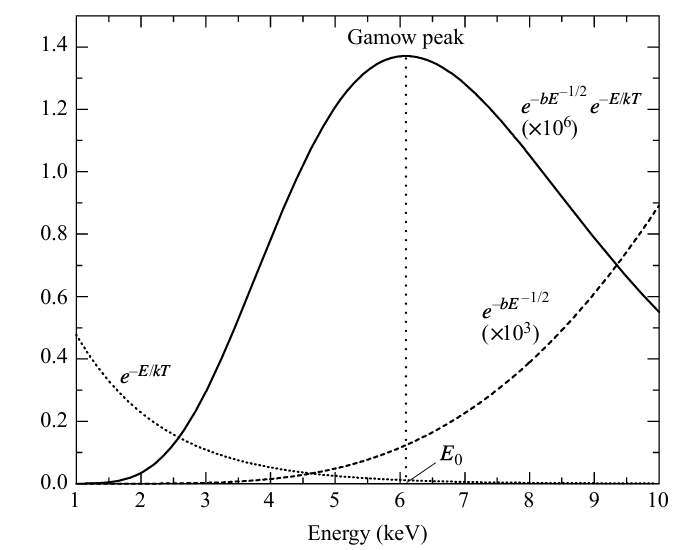

Let’s take a look to the Gamow peak. If we calculate the value of the peak, we could get the approximation below:
$$E_G=(Z^2_1 Z^2_2 T^2)^{\frac{1}{3}}$$

- $E_G$ is the peak energy
- $Z_1, Z_2$ is the number of charges

### Proton–Proton Chain

- A chain reaction that turns H into He
- $\epsilon\varpropto\rho T^4$

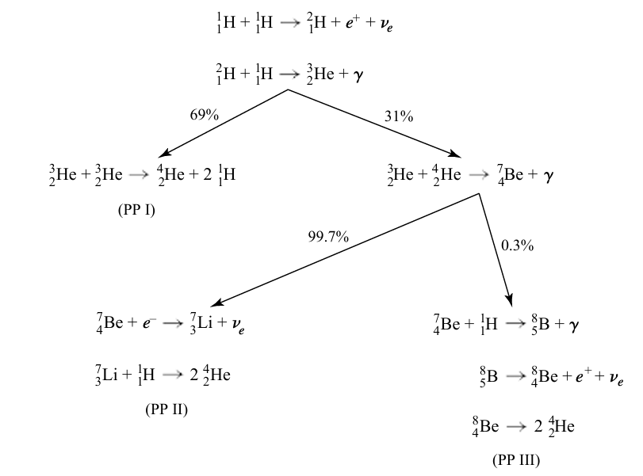

  ### CNO cycle
- Using CNO as catalysts
- Much more temperature-dependent than pp chain
- $\epsilon\varpropto\rho T^{19.9}$ (WTF??)

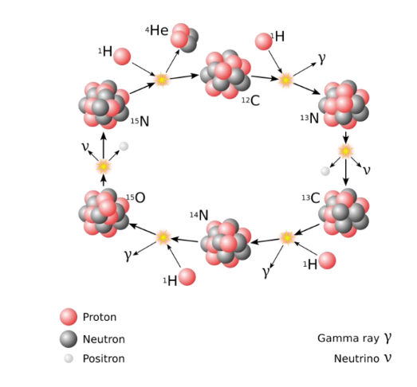

### Triple alpha reaction

$$\epsilon\varpropto\rho T^{41.0}$$
Bro WTF is this shit?

### Carbon and oxygen burning

# Energy transport mechanisms

**Conduction sucks as fuck**

## Radiation

### Radiation pressure gradient

Temperature in a star decreases outward, so radiation pressure is lower outside
$$\frac{dP_{rad}}{dr}=\frac{\bar{\kappa}\rho}{c}F_{rad}=\frac{4}{3}aT^3\frac{dT}{dr}\
\ (F_{rad}=\frac{L_r}{4\pi r^2})$$

- $F_{rad}$ is the energy released from the shell at r per second

Therefore, we could get the temp. gradient of radiation
$$\frac{dT}{dr}=\frac{-3}{4ac}\frac{\bar{\kappa}\rho}{T^3}\frac{L_r}{4\pi
r^2}$$

- Change with opacity, density, temperature and luminosity
- Temperature decreases as we move outward. Energy flows from the hot core to the cooler outer layers.
- High opacity, density and flux impede radiative energy transport, requiring a steeper temperature gradient to maintain the energy flow.

You can easily think the higher temp. gradient, the harder radiation to transport energy.

## Convection

**Bro this part is hard as fuck

### Scale height

First we define pressure scale height
$$\frac{1}{H_{P}}=-\frac{1}{P}
\frac{dP}{dr}$$
If we assume it’s constant. we can solve this differential equation.
$$P=P_{0}\
e^{-r/H_{P}}$$
Think its physical meaning:)

### Adiabatic process

Consider a convective bubble traveling outward a distance $dr$ under adiabatic condition, we can derive its temp. gradient. In addition, through some thermodynamic process, we can get adiabatic gas law
$$\gamma \frac{dV}{V}=-\frac{dP}{P}$$
$$\implies PV^\gamma=\text{constant}$$
$$\implies P=K\rho^\gamma$$
- K is constant

Recall ideal gas law, $P=\frac{\rho kT}{\mu m_{H}}$, do total differential
$$\frac{dP}{dr}=-\frac{P}{\mu}
\frac{d\mu}{dr}+\frac{P}{\rho} \frac{d\rho}{dr}+\frac{P}{T}
\frac{dT}{dr}$$
Combine two results, assume $\mu$ is a constant
$$\frac{dT}{dr}|_{ad}=\left( 1-\frac{1}{\gamma}
\right) \frac{T}{P} \frac{dP}{dr}=-\left( 1-\frac{1}{\gamma} \right)
\frac{\mu m_{H}}{k} \frac{GM_{r}}{r^2}$$
This is how the temperature of the gas inside the bubble changes Take $g=GM_{r}/r^2,\ k/\mu m_{H}=nR,\ C_{P}-C_{V}=nR$, we can rewrite the equation
$$\frac{dT}{dr}|_{ad}=-\frac{g}{C_{P}}$$
If the actual temperature gradient is steeper, than it’s called superadiabatic, and convection can carry nearly all luminosity out
$$|\frac{dT}{dr}|_{\text{actuall}}>|\frac{dT}{dr}|_{\text{ad}}$$
- Remember they are negative

Hence, for convection to occur,
$$\frac{d\ln P}{d\ln T}<
\frac{\gamma}{\gamma-1}$$
But actually, temperature gradient can only be slightly superadiabatic for convection to carry out most energy in the center # Brief Summary
$$\frac{dP}{dr}=-G\frac{M_r\rho}{r^2}=-\rho
g$$
$$\frac{dM_r}{dr}= 4\pi
r^2\rho$$
$$\frac{dL_r}{dr}=4\pi r^2\
\rho\epsilon$$
$$\frac{dT}{dr}=\frac{-3}{4ac}\frac{\bar{\kappa}\rho}{T^3}\frac{L_r}{4\pi
r^2}(\mbox{radiation})=-(1-\frac{1}{\gamma})\frac{\mu
m_H}{k}\frac{GM_r}{r^2}(\mbox{adiabatic})$$